# Exploratory Data Analysis on Crop Production in India

I will be analyzing the Agriculture Crop Production dataset and try to answer some interesting questions. I have downloaded the dataset from Kaggle datasets.The libraries for data analysis and visualization that I have used in this project are Numpy, Pandas, Matplotlib and Seaborn.

# Data Preparation and cleaning

- Load the file using Pandas
- Look at some information about the data
- Fix any missing values

# Required Library

```python
import pandas as pd
import numpy as np
import matplotlib.pyplot as plt
import seaborn as sns
import warnings
warnings.filterwarnings('ignore')
```

# Load Dataset

```python
df = pd.read_csv('C:\\Users\\KALI LINNUX\\Desktop\\Data Analysis\\crop production\\Crop Production data.csv')
```

# Top 5 Row

```python
df.head()
```

|  | State_Name | District_Name | Crop_Year | Season | Crop | Area | Production |
| --- | --- | --- | --- | --- | --- | --- | --- |
| 0 | Andaman and Nicobar Islands | NICOBARS | 2000 | Kharif | Arecanut | 1254.0 | 2000.0 |
| 1 | Andaman and Nicobar Islands | NICOBARS | 2000 | Kharif | Other Kharif pulses | 2.0 | 1.0 |
| 2 | Andaman and Nicobar Islands | NICOBARS | 2000 | Kharif | Rice | 102.0 | 321.0 |
| 3 | Andaman and Nicobar Islands | NICOBARS | 2000 | Whole Year | Banana | 176.0 | 641.0 |
| 4 | Andaman and Nicobar Islands | NICOBARS | 2000 | Whole Year | Cashewnut | 720.0 | 165.0 |

# Last 5 Row

```python
df.tail()
```

|  | State_Name | District_Name | Crop_Year | Season | Crop | Area | Production |
| --- | --- | --- | --- | --- | --- | --- | --- |
| 246086 | West Bengal | PURULIA | 2014 | Summer | Rice | 306.0 | 801.0 |
| 246087 | West Bengal | PURULIA | 2014 | Summer | Sesamum | 627.0 | 463.0 |
| 246088 | West Bengal | PURULIA | 2014 | Whole Year | Sugarcane | 324.0 | 16250.0 |
| 246089 | West Bengal | PURULIA | 2014 | Winter | Rice | 279151.0 | 597899.0 |
| 246090 | West Bengal | PURULIA | 2014 | Winter | Sesamum | 175.0 | 88.0 |

# Random 5 Rows

```python
df.sample(5)
```

|  | State_Name | District_Name | Crop_Year | Season | Crop | Area | Production |
| --- | --- | --- | --- | --- | --- | --- | --- |
| 165252 | Rajasthan | ALWAR | 2009 | Whole Year | Sweet potato | 20.0 | NaN |
| 111733 | Madhya Pradesh | JABALPUR | 2002 | Whole Year | Sannhamp | 39.0 | 89.0 |
| 127359 | Maharashtra | BHANDARA | 1998 | Kharif | Soyabean | 11900.0 | 20000.0 |
| 72190 | Himachal Pradesh | KANGRA | 2001 | Whole Year | Garlic | 49.0 | 65.0 |
| 114961 | Madhya Pradesh | MANDSAUR | 2009 | Whole Year | Garlic | 6519.0 | 27568.0 |

# Shape of dataset

```python
df.shape
```

```
(246091, 7)
```

```python
print(f'The Given dataset contain Rows is : {246091}')
print(f'The Given dataset contain Columns is : {7}')
```

```
The Given dataset contain Rows is : 246091
The Given dataset contain Columns is : 7
```

# Total size of dataset

```python
df.size
```

```
1722637
```

```python
print(f'The given dataset size is : {1722637}')
```

```
The given dataset size is : 1722637
```

# Basic Information about dataset

```python
df.info()
```

```
<class 'pandas.core.frame.DataFrame'>
RangeIndex: 246091 entries, 0 to 246090
Data columns (total 7 columns):
 #   Column         Non-Null Count   Dtype
---  ------         --------------   -----
 0   State_Name     246091 non-null  object
 1   District_Name  246091 non-null  object
 2   Crop_Year      246091 non-null  int64
 3   Season         246091 non-null  object
 4   Crop           246091 non-null  object
 5   Area           246091 non-null  float64
 6   Production     242361 non-null  float64
dtypes: float64(2), int64(1), object(4)
memory usage: 13.1+ MB
```

# Statical information about dataset

```python
df.describe()
```

|  | Crop_Year | Area | Production |
| --- | --- | --- | --- |
| count | 246091.000000 | 2.460910e+05 | 2.423610e+05 |
| mean | 2005.643018 | 1.200282e+04 | 5.825034e+05 |
| std | 4.952164 | 5.052340e+04 | 1.706581e+07 |
| min | 1997.000000 | 4.000000e-02 | 0.000000e+00 |
| 25% | 2002.000000 | 8.000000e+01 | 8.800000e+01 |
| 50% | 2006.000000 | 5.820000e+02 | 7.290000e+02 |
| 75% | 2010.000000 | 4.392000e+03 | 7.023000e+03 |
| max | 2015.000000 | 8.580100e+06 | 1.250800e+09 |

## Checking for Missing Data

```python
df.isna().sum()
```

```
State_Name          0
District_Name       0
Crop_Year           0
Season              0
Crop                0
Area                0
Production       3730
dtype: int64
```

```python
3730/ 246091
```

```
0.015156994770227274
```

```python
# Dropping the sample having missing data
df.dropna(subset=['Production'], axis=0, inplace=True)
```

```python
df.describe()
```

|  | Crop_Year | Area | Production |
| --- | --- | --- | --- |
| count | 242361.000000 | 2.423610e+05 | 2.423610e+05 |
| mean | 2005.625773 | 1.216741e+04 | 5.825034e+05 |
| std | 4.958285 | 5.085744e+04 | 1.706581e+07 |
| min | 1997.000000 | 1.000000e-01 | 0.000000e+00 |
| 25% | 2002.000000 | 8.700000e+01 | 8.800000e+01 |
| 50% | 2006.000000 | 6.030000e+02 | 7.290000e+02 |
| 75% | 2010.000000 | 4.545000e+03 | 7.023000e+03 |
| max | 2015.000000 | 8.580100e+06 | 1.250800e+09 |

```python
df.shape
```

```
(242361, 7)
```

# Exploratory Analysis and Visualization

## Univarate Analysis

### STATE

```python
# STATES
states = df.State_Name.str.strip().unique()
states
```

```
array(['Andaman and Nicobar Islands', 'Andhra Pradesh',
       'Arunachal Pradesh', 'Assam', 'Bihar', 'Chandigarh',
       'Chhattisgarh', 'Dadra and Nagar Haveli', 'Goa', 'Gujarat',
       'Haryana', 'Himachal Pradesh', 'Jammu and Kashmir', 'Jharkhand',
       'Karnataka', 'Kerala', 'Madhya Pradesh', 'Maharashtra', 'Manipur',
       'Meghalaya', 'Mizoram', 'Nagaland', 'Odisha', 'Puducherry',
       'Punjab', 'Rajasthan', 'Sikkim', 'Tamil Nadu', 'Telangana',
       'Tripura', 'Uttar Pradesh', 'Uttarakhand', 'West Bengal'],
      dtype=object)
```

```python
len(states)
```

```
33
```

```python
df.State_Name.value_counts()
```

```
State_Name
Uttar Pradesh                  33189
Madhya Pradesh                 22604
Karnataka                      21079
Bihar                          18874
Assam                          14622
Odisha                         13524
Tamil Nadu                     13266
Maharashtra                    12496
Rajasthan                      12066
Chhattisgarh                   10368
West Bengal                     9597
Andhra Pradesh                  9561
Gujarat                         8365
Telangana                       5591
Uttarakhand                     4825
Haryana                         4540
Kerala                          4003
Nagaland                        3904
Punjab                          3143
Meghalaya                       2867
Arunachal Pradesh               2545
Himachal Pradesh                2456
Jammu and Kashmir               1632
Tripura                         1412
Manipur                         1266
Jharkhand                       1266
Mizoram                          954
Puducherry                       872
Sikkim                           714
Dadra and Nagar Haveli           263
Goa                              207
Andaman and Nicobar Islands      201
Chandigarh                        89
Name: count, dtype: int64
```

- We have data from 33 states (including union territories).
- We have more data from top agriculture rich states like Uttar Pradesh, Madhya Pradesh and Karnataka than other states.

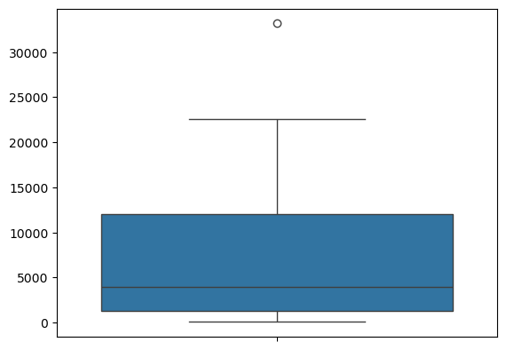

```python
sns.boxplot(df.State_Name.value_counts().values)
```

### District

```python
(len(df.District_Name.unique()),
df.District_Name.unique())
```

```
(646,
 array(['NICOBARS', 'NORTH AND MIDDLE ANDAMAN', 'SOUTH ANDAMANS',
        'ANANTAPUR', 'CHITTOOR', 'EAST GODAVARI', 'GUNTUR', 'KADAPA',
        'KRISHNA', 'KURNOOL', 'PRAKASAM', 'SPSR NELLORE', 'SRIKAKULAM',
        'VISAKHAPATANAM', 'VIZIANAGARAM', 'WEST GODAVARI', 'ANJAW',
        'CHANGLANG', 'DIBANG VALLEY', 'EAST KAMENG', 'EAST SIANG',
        'KURUNG KUMEY', 'LOHIT', 'LONGDING', 'LOWER DIBANG VALLEY',
        'LOWER SUBANSIRI', 'NAMSAI', 'PAPUM PARE', 'TAWANG', 'TIRAP',
        'UPPER SIANG', 'UPPER SUBANSIRI', 'WEST KAMENG', 'WEST SIANG',
        'BAKSA', 'BARPETA', 'BONGAIGAON', 'CACHAR', 'CHIRANG', 'DARRANG',
        'DHEMAJI', 'DHUBRI', 'DIBRUGARH', 'DIMA HASAO', 'GOALPARA',
        'GOLAGHAT', 'HAILAKANDI', 'JORHAT', 'KAMRUP', 'KAMRUP METRO',
        'KARBI ANGLONG', 'KARIMGANJ', 'KOKRAJHAR', 'LAKHIMPUR', 'MARIGAON',
        'NAGAON', 'NALBARI', 'SIVASAGAR', 'SONITPUR', 'TINSUKIA',
        'UDALGURI', 'ARARIA', 'ARWAL', 'AURANGABAD', 'BANKA', 'BEGUSARAI',
        'BHAGALPUR', 'BHOJPUR', 'BUXAR', 'DARBHANGA', 'GAYA', 'GOPALGANJ',
        'JAMUI', 'JEHANABAD', 'KAIMUR (BHABUA)', 'KATIHAR', 'KHAGARIA',
        'KISHANGANJ', 'LAKHISARAI', 'MADHEPURA', 'MADHUBANI', 'MUNGER',
        'MUZAFFARPUR', 'NALANDA', 'NAWADA', 'PASHCHIM CHAMPARAN', 'PATNA',
        'PURBI CHAMPARAN', 'PURNIA', 'ROHTAS', 'SAHARSA', 'SAMASTIPUR',
        'SARAN', 'SHEIKHPURA', 'SHEOHAR', 'SITAMARHI', 'SIWAN', 'SUPAUL',
        'VAISHALI', 'CHANDIGARH', 'BALOD', 'BALODA BAZAR', 'BALRAMPUR',
        'BASTAR', 'BEMETARA', 'BIJAPUR', 'BILASPUR', 'DANTEWADA',
        'DHAMTARI', 'DURG', 'GARIYABAND', 'JANJGIR-CHAMPA', 'JASHPUR',
        'KABIRDHAM', 'KANKER', 'KONDAGAON', 'KORBA', 'KOREA', 'MAHASAMUND',
        'MUNGELI', 'NARAYANPUR', 'RAIGARH', 'RAIPUR', 'RAJNANDGAON',
        'SUKMA', 'SURAJPUR', 'SURGUJA', 'DADRA AND NAGAR HAVELI',
        'NORTH GOA', 'SOUTH GOA', 'AHMADABAD', 'AMRELI', 'ANAND',
        'BANAS KANTHA', 'BHARUCH', 'BHAVNAGAR', 'DANG', 'DOHAD',
        'GANDHINAGAR', 'JAMNAGAR', 'JUNAGADH', 'KACHCHH', 'KHEDA',
        'MAHESANA', 'NARMADA', 'NAVSARI', 'PANCH MAHALS', 'PATAN',
        'PORBANDAR', 'RAJKOT', 'SABAR KANTHA', 'SURAT', 'SURENDRANAGAR',
        'TAPI', 'VADODARA', 'VALSAD', 'AMBALA', 'BHIWANI', 'FARIDABAD',
        'FATEHABAD', 'GURGAON', 'HISAR', 'JHAJJAR', 'JIND', 'KAITHAL',
        'KARNAL', 'KURUKSHETRA', 'MAHENDRAGARH', 'MEWAT', 'PALWAL',
        'PANCHKULA', 'PANIPAT', 'REWARI', 'ROHTAK', 'SIRSA', 'SONIPAT',
        'YAMUNANAGAR', 'CHAMBA', 'HAMIRPUR', 'KANGRA', 'KINNAUR', 'KULLU',
        'LAHUL AND SPITI', 'MANDI', 'SHIMLA', 'SIRMAUR', 'SOLAN', 'UNA',
        'ANANTNAG', 'BADGAM', 'BANDIPORA', 'BARAMULLA', 'DODA',
        'GANDERBAL', 'JAMMU', 'KARGIL', 'KATHUA', 'KISHTWAR', 'KULGAM',
```

[output cut: 74 more lines]

```
        'JHANSI', 'KANNAUJ', 'KANPUR DEHAT', 'KANPUR NAGAR', 'KASGANJ',
        'KAUSHAMBI', 'KHERI', 'KUSHI NAGAR', 'LALITPUR', 'LUCKNOW',
        'MAHARAJGANJ', 'MAHOBA', 'MAINPURI', 'MATHURA', 'MAU', 'MEERUT',
        'MIRZAPUR', 'MORADABAD', 'MUZAFFARNAGAR', 'PILIBHIT', 'RAE BARELI',
        'RAMPUR', 'SAHARANPUR', 'SAMBHAL', 'SANT KABEER NAGAR',
        'SANT RAVIDAS NAGAR', 'SHAHJAHANPUR', 'SHAMLI', 'SHRAVASTI',
        'SIDDHARTH NAGAR', 'SITAPUR', 'SONBHADRA', 'SULTANPUR', 'UNNAO',
        'VARANASI', 'ALMORA', 'BAGESHWAR', 'CHAMOLI', 'CHAMPAWAT',
        'DEHRADUN', 'HARIDWAR', 'NAINITAL', 'PAURI GARHWAL', 'PITHORAGARH',
        'RUDRA PRAYAG', 'TEHRI GARHWAL', 'UDAM SINGH NAGAR', 'UTTAR KASHI',
        '24 PARAGANAS NORTH', '24 PARAGANAS SOUTH', 'BANKURA', 'BARDHAMAN',
        'BIRBHUM', 'COOCHBEHAR', 'DARJEELING', 'DINAJPUR DAKSHIN',
        'DINAJPUR UTTAR', 'HOOGHLY', 'HOWRAH', 'JALPAIGURI', 'MALDAH',
        'MEDINIPUR EAST', 'MEDINIPUR WEST', 'MURSHIDABAD', 'NADIA',
        'PURULIA'], dtype=object))
```

```python
df.District_Name.value_counts()
```

```
District_Name
TUMKUR       931
BELGAUM      924
BIJAPUR      905
HASSAN       895
BELLARY      887
            ...
HYDERABAD      8
KHUNTI         6
RAMGARH        6
NAMSAI         1
MUMBAI         1
Name: count, Length: 646, dtype: int64
```

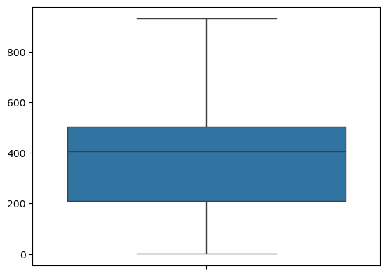

```python
sns.boxplot(df.District_Name.value_counts().values)
```

### Crop Year

```python
# CROP YEARS

print(df.Crop_Year.nunique())
print(df.Crop_Year.min())
print(df.Crop_Year.max())
```

```
19
1997
2015
```

```python
df.Crop_Year.unique()
```

```
array([2000, 2001, 2002, 2003, 2004, 2005, 2006, 2010, 1997, 1998, 1999,
       2007, 2008, 2009, 2011, 2012, 2013, 2014, 2015], dtype=int64)
```

```python
df.Crop_Year.value_counts()
```

```
Crop_Year
2003    17139
2002    16536
2007    14269
2008    14230
2006    13976
2004    13858
2010    13793
2011    13791
2009    13767
2000    13553
2005    13519
2013    13475
2001    13293
2012    13184
1999    12441
1998    11262
2014    10815
1997     8899
2015      561
Name: count, dtype: int64
```

- We have data of 19 years from 1997 to 2015.
- The years having more data are - 2003, 2002, 2007, 2008 and 2006

### Season

```python
# Season
print(df.Season.nunique())
df.Season = df.Season.str.strip()
```

```
6
```

```python
Seasons = df.Season.unique()
Seasons
```

```
array(['Kharif', 'Whole Year', 'Autumn', 'Rabi', 'Summer', 'Winter'],
      dtype=object)
```

```python
df.Season.max()
```

```
'Winter'
```

```python
df.Season.value_counts()
```

```
Season
Kharif        94283
Rabi          66160
Whole Year    56127
Summer        14811
Winter         6050
Autumn         4930
Name: count, dtype: int64
```

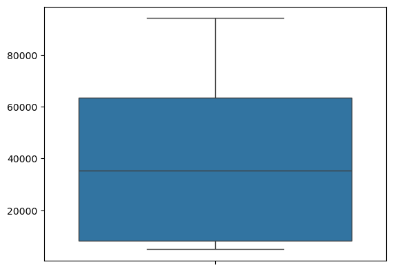

```python
sns.boxplot(df.Season.value_counts().values)
```

### Crop

```python
print(df.Crop.nunique())
```

```
124
```

```python
Crop = df.Crop.unique()
Crop
```

```
array(['Arecanut', 'Other Kharif pulses', 'Rice', 'Banana', 'Cashewnut',
       'Coconut ', 'Dry ginger', 'Sugarcane', 'Sweet potato', 'Tapioca',
       'Black pepper', 'Dry chillies', 'other oilseeds', 'Turmeric',
       'Maize', 'Moong(Green Gram)', 'Urad', 'Arhar/Tur', 'Groundnut',
       'Sunflower', 'Bajra', 'Castor seed', 'Cotton(lint)', 'Horse-gram',
       'Jowar', 'Korra', 'Ragi', 'Tobacco', 'Gram', 'Wheat', 'Masoor',
       'Sesamum', 'Linseed', 'Safflower', 'Onion', 'other misc. pulses',
       'Samai', 'Small millets', 'Coriander', 'Potato',
       'Other  Rabi pulses', 'Soyabean', 'Beans & Mutter(Vegetable)',
       'Bhindi', 'Brinjal', 'Citrus Fruit', 'Cucumber', 'Grapes', 'Mango',
       'Orange', 'other fibres', 'Other Fresh Fruits', 'Other Vegetables',
       'Papaya', 'Pome Fruit', 'Tomato', 'Mesta', 'Cowpea(Lobia)',
       'Lemon', 'Pome Granet', 'Sapota', 'Cabbage', 'Rapeseed &Mustard',
       'Peas  (vegetable)', 'Niger seed', 'Bottle Gourd', 'Varagu',
       'Garlic', 'Ginger', 'Oilseeds total', 'Pulses total', 'Jute',
       'Peas & beans (Pulses)', 'Blackgram', 'Paddy', 'Pineapple',
       'Barley', 'Sannhamp', 'Khesari', 'Guar seed', 'Moth',
       'Other Cereals & Millets', 'Cond-spcs other', 'Turnip', 'Carrot',
       'Redish', 'Arcanut (Processed)', 'Atcanut (Raw)',
       'Cashewnut Processed', 'Cashewnut Raw', 'Cardamom', 'Rubber',
       'Bitter Gourd', 'Drum Stick', 'Jack Fruit', 'Snak Guard', 'Tea',
       'Coffee', 'Cauliflower', 'Other Citrus Fruit', 'Water Melon',
       'Total foodgrain', 'Kapas', 'Colocosia', 'Lentil', 'Bean',
       'Jobster', 'Perilla', 'Rajmash Kholar', 'Ricebean (nagadal)',
       'Ash Gourd', 'Beet Root', 'Lab-Lab', 'Ribed Guard', 'Yam',
       'Pump Kin', 'Apple', 'Peach', 'Pear', 'Plums', 'Litchi', 'Ber',
       'Other Dry Fruit', 'Jute & mesta'], dtype=object)
```

```python
df.Crop.value_counts().head(25)
```

```
Crop
Rice                     15082
Maize                    13787
Moong(Green Gram)        10106
Urad                      9710
Sesamum                   8821
Groundnut                 8770
Wheat                     7878
Sugarcane                 7827
Rapeseed &Mustard         7533
Arhar/Tur                 7476
Gram                      7227
Jowar                     6990
Onion                     6984
Potato                    6914
Dry chillies              6421
Sunflower                 5483
Bajra                     5379
Small millets             4593
Peas & beans (Pulses)     4447
Cotton(lint)              4382
Linseed                   4351
Turmeric                  4168
Masoor                    4152
Sweet potato              4122
Barley                    4116
Name: count, dtype: int64
```

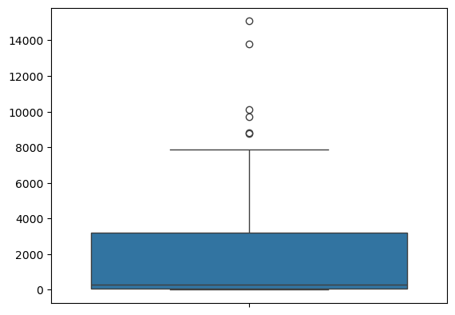

```python
sns.boxplot(df.Crop.value_counts().values)
```

### Area

```python
# Area
print(df.Area.max())
print(df.Area.min())
```

```
8580100.0
0.1
```

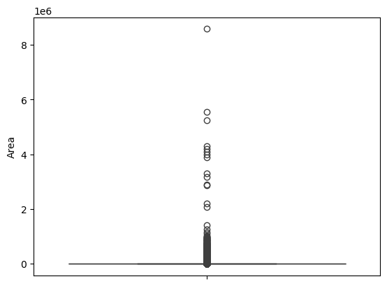

```python
sns.boxplot(df.Area)
```

### Production

```python
df.Production.describe()
```

```
count    2.423610e+05
mean     5.825034e+05
std      1.706581e+07
min      0.000000e+00
25%      8.800000e+01
50%      7.290000e+02
75%      7.023000e+03
max      1.250800e+09
Name: Production, dtype: float64
```

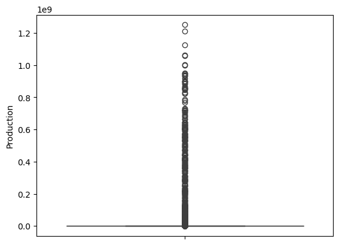

```python
sns.boxplot(df.Production)
```

### Create two columns Total Production and Productivity.

### Total Production

```python
df['Total Production'] = df['Production'] * df['Area']
```

```python
df['Total Production']
```

```
0         2.508000e+06
1         2.000000e+00
2         3.274200e+04
3         1.128160e+05
4         1.188000e+05
              ...
246086    2.451060e+05
246087    2.903010e+05
246088    5.265000e+06
246089    1.669041e+11
246090    1.540000e+04
Name: Total Production, Length: 242361, dtype: float64
```

### Remove Outliers

```python
Q1= df["Total Production"].quantile(0.40)
Q3 =df["Total Production"].quantile (0.60)
IQR = Q3 - Q1
df =df[(df["Total Production"] >= Q1-1.5*IQR) & (df ["Total Production"] <= Q3 + 1.5*IQR)]
```

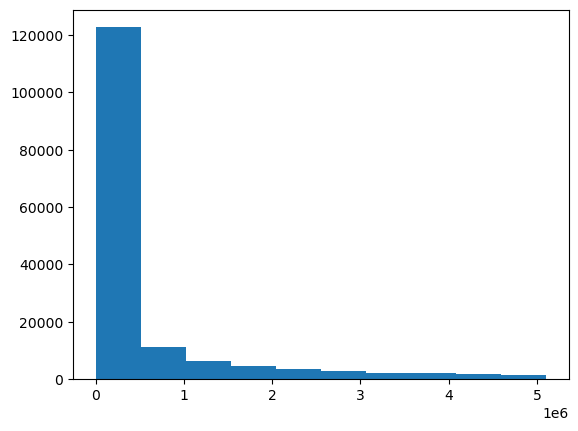

```python
plt.hist(df['Total Production'])
```

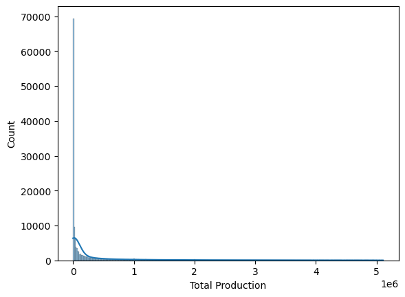

```python
sns.histplot(df['Total Production'], kde = True)
```

### Productivity

```python
df['Productivity'] = df['Production'] / df['Area']
```

```python
df['Productivity']
```

```
1         0.500000
4         0.229167
11        0.500000
13        0.267038
16        1.000000
            ...
246081    0.800000
246082    0.685185
246083    0.513636
246087    0.738437
246090    0.502857
Name: Productivity, Length: 103594, dtype: float64
```

```python
Q1 =df ["Productivity"].quantile (0.40)
Q3 =df["Productivity"].quantile (0.60)

IQR= Q3-Q1

df=df[(df["Productivity"] >= Q1 -1.5*IQR) & (df ["Productivity"] <= Q3 + 1.5*IQR)]
```

```python
df['Productivity']
```

```
1         0.500000
4         0.229167
11        0.500000
13        0.267038
16        1.000000
            ...
246081    0.800000
246082    0.685185
246083    0.513636
246087    0.738437
246090    0.502857
Name: Productivity, Length: 86161, dtype: float64
```

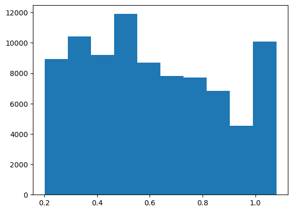

```python
plt.hist(df['Productivity'])
plt.show()
```

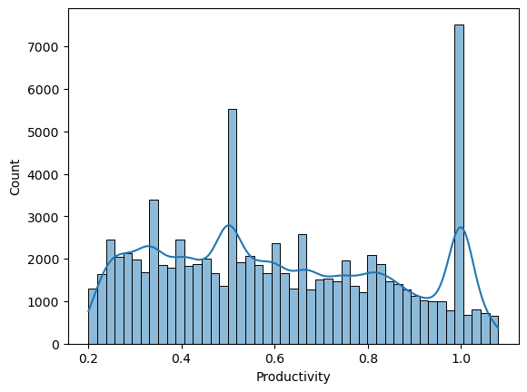

```python
sns.histplot(df['Productivity'], kde = True)
```

### Area

```python
df.Area
```

```
1            2.0
4          720.0
11           2.0
13         719.0
16           1.0
           ...
246081    1885.0
246082      54.0
246083     220.0
246087     627.0
246090     175.0
Name: Area, Length: 86161, dtype: float64
```

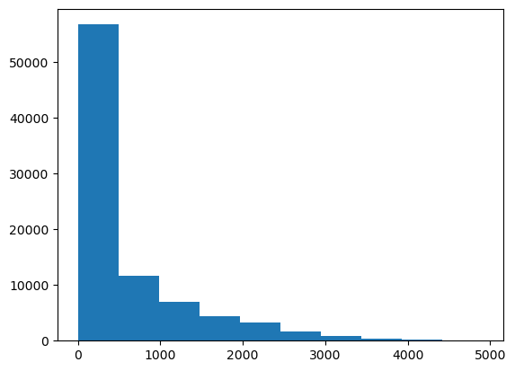

```python
plt.hist(df['Area'])
```

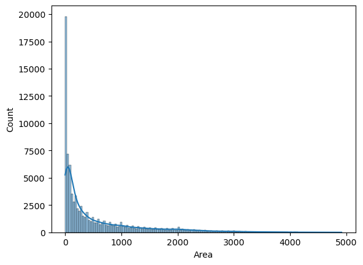

```python
sns.histplot(df['Area'], kde = True)
```

### Production

```python
df.Production
```

```
1            1.0
4          165.0
11           1.0
13         192.0
16           1.0
           ...
246081    1508.0
246082      37.0
246083     113.0
246087     463.0
246090      88.0
Name: Production, Length: 86161, dtype: float64
```

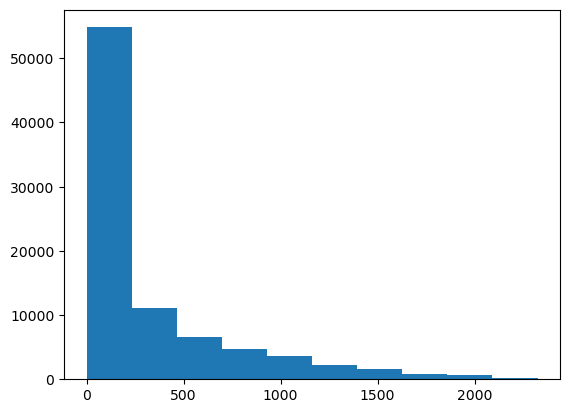

```python
plt.hist(df['Production'])
```

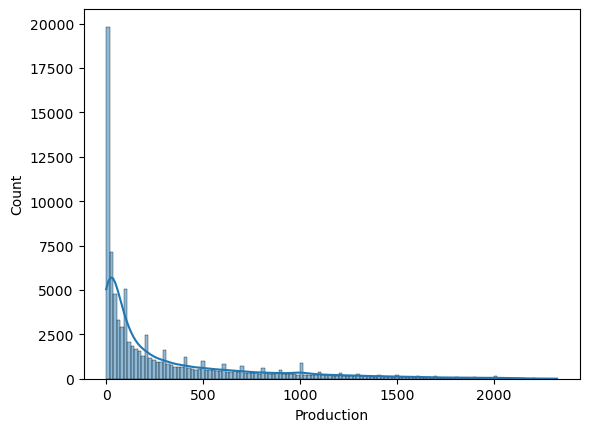

```python
sns.histplot(df['Production'], kde=True)
```

## Plot crop production over the years.

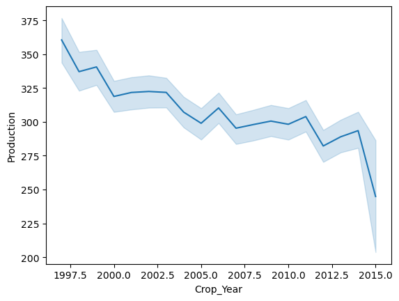

```python
sns.lineplot(x='Crop_Year', y='Production', data = df)
plt.show()
```

## Plot crop production by crop

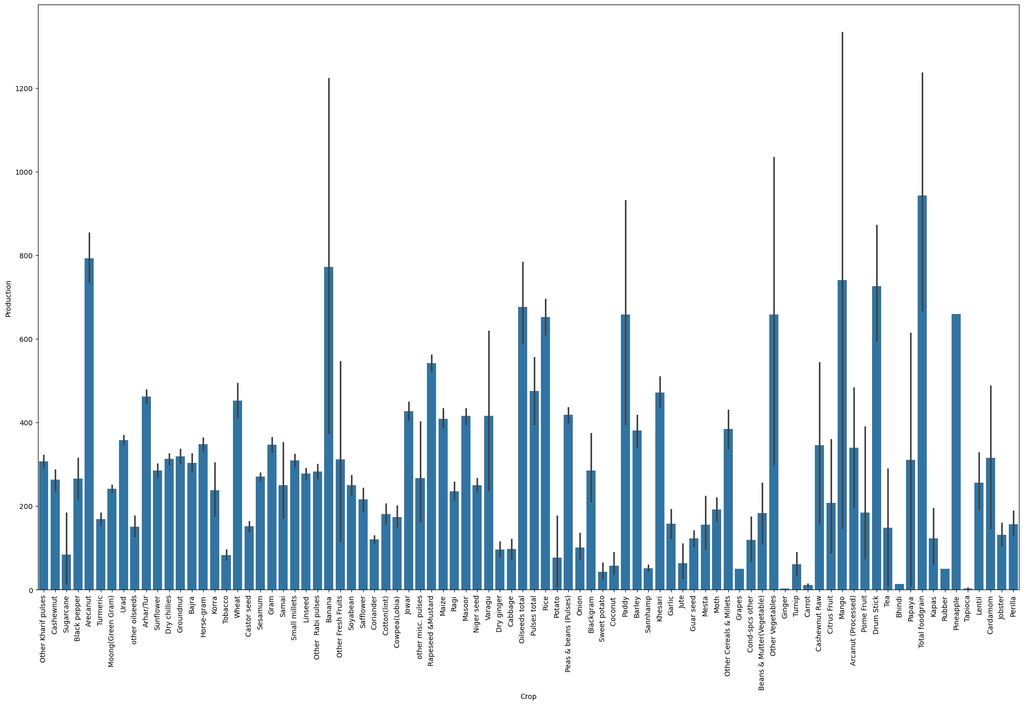

```python
plt.figure(figsize=(25,15))
sns.barplot(x='Crop', y='Production', data = df)
plt.xticks(rotation = 90)
plt.show()
```

## Plot crop production by state

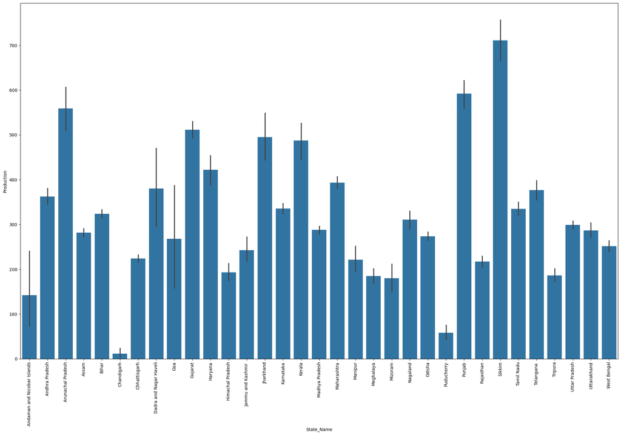

```python
plt.figure(figsize=(25,15))
sns.barplot(x='State_Name', y='Production', data = df)
plt.xticks(rotation = 90)
plt.show()
```

## Plot crop production by season

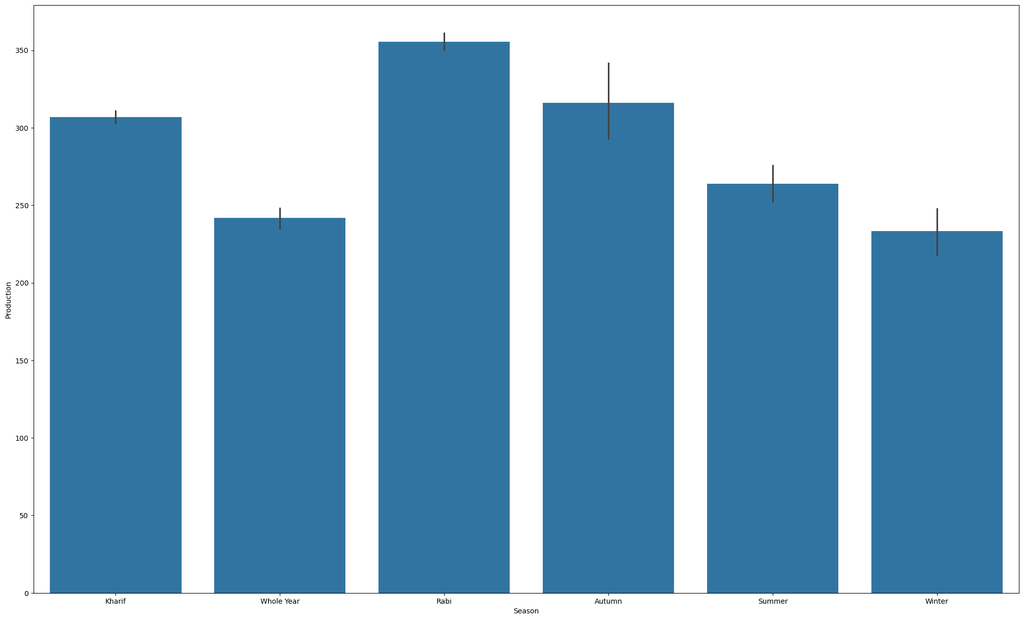

```python
plt.figure(figsize=(25,15))
sns.barplot(x='Season', y='Production', data = df)
plt.show()
```

```python
crop = df['Crop']
```

```python
def crop_category(crop):
    for i in ['Rice','Maize','Wheat','Barley','Varagu','Other Cereals & Millets','Ragi','Small millets','Bajra','Jowar', 'Paddy','Total foodgrain','Jobster']:
        if crop==i:
            return 'Cereal'
    for i in ['Moong','Urad','Arhar/Tur','Peas & beans','Masoor',
              'Other Kharif pulses','other misc. pulses','Ricebean (nagadal)',
              'Rajmash Kholar','Lentil','Samai','Blackgram','Korra','Cowpea(Lobia)',
              'Other  Rabi pulses','Other Kharif pulses','Peas & beans (Pulses)','Pulses total','Gram']:
        if crop==i:
            return 'Pulses'
    for i in ['Peach','Apple','Litchi','Pear','Plums','Ber','Sapota','Lemon','Pome Granet',
               'Other Citrus Fruit','Water Melon','Jack Fruit','Grapes','Pineapple','Orange',
               'Pome Fruit','Citrus Fruit','Other Fresh Fruits','Mango','Papaya','Coconut','Banana']:
        if crop==i:
            return 'Fruits'
    for i in ['Bean','Lab-Lab','Moth','Guar seed','Soyabean','Horse-gram']:
        if crop==i:
            return 'Beans'
    for i in ['Turnip','Peas','Beet Root','Carrot','Yam','Ribed Guard','Ash Gourd ','Pump Kin','Redish','Snak Guard','Bottle Gourd',
              'Bitter Gourd','Cucumber','Drum Stick','Cauliflower','Beans & Mutter(Vegetable)','Cabbage',
              'Bhindi','Tomato','Brinjal','Khesari','Sweet potato','Potato','Onion','Tapioca','Colocosia']:
              if crop==i:
                return 'Vegetables'
    for i in ['Perilla','Ginger','Cardamom','Black pepper','Dry ginger','Garlic','Coriander','Turmeric','Dry chillies','Cond-spcs other']:
        if crop==i:
            return 'spices'
    for i in ['other fibres','Kapas','Jute & mesta','Jute','Mesta','Cotton(lint)','Sannhamp']:
        if crop==i:
            return 'fibres'
    for i in ['Arcanut (Processed)','Atcanut (Raw)','Cashewnut Processed','Cashewnut Raw','Cashewnut','Arecanut','Groundnut']:
        if crop==i:
            return 'Nuts'
    for i in ['other oilseeds','Safflower','Niger seed','Castor seed','Linseed','Sunflower','Rapeseed &Mustard','Sesamum','Oilseeds total']:
        if crop==i:
            return 'Oilseeds'
    for i in ['Tobacco','Coffee','Tea','Sugarcane','Rubber']:
        if crop==i:
            return 'Commercial'

df['crop_category']=df['Crop'].apply(crop_category)
```

```python
df['crop_category'].value_counts()
```

[output not shown]

```python
# NEW VARIABLE - PRODUCTION PER UNIT AREA
df['Production_per_unit_area'] = df['Production'] / df['Area']
```

```python
df.Production_per_unit_area
```

[output not shown]

# Visualising Data

## 1. State wise Production

```python
prod = df.groupby(by = df.State_Name)['Production'].sum().reset_index().sort_values(by = 'Production', ascending = False)
prod
```

[output not shown]

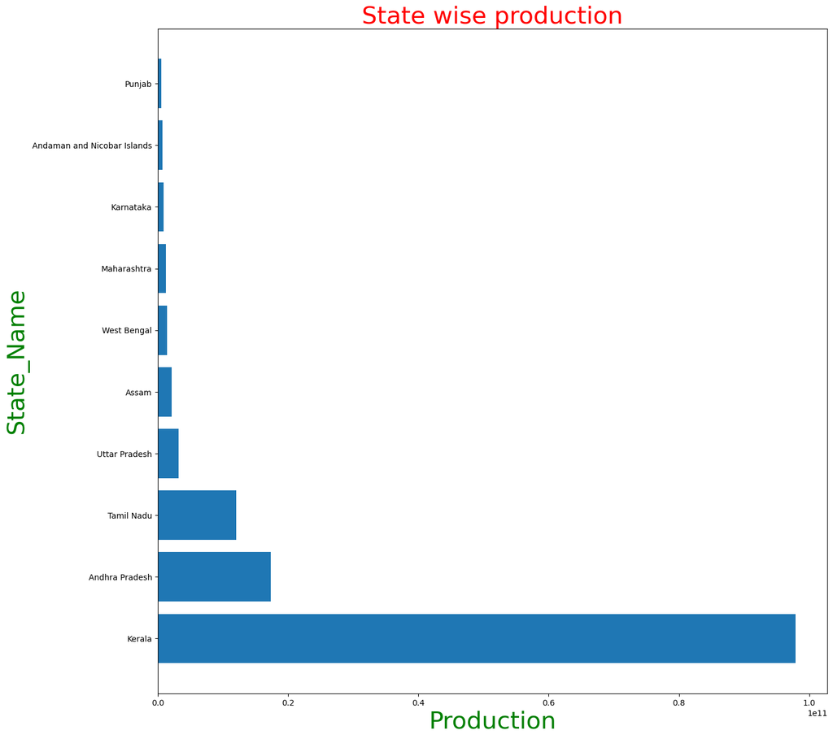

```python
plt.figure(figsize=(15,15))
x = prod['Production'].head(10)
y = prod['State_Name'].head(10)
plt.barh( y,x)
plt.title('State wise production', fontsize= 30 , color = 'r')
plt.xlabel('Production', fontsize = 30 , color = 'g')
plt.ylabel('State_Name', fontsize = 30, color = 'g')
plt.show()
```

```python
df.Production.describe()
```

[output not shown]

## 2. Crop wise Production

```python
# TOP 10 CROPS BY PRODUCTION
crop1 = df.groupby(by='Crop')['Production'].sum().reset_index().sort_values(by='Production', ascending=False).head(10)
crop1
```

[output not shown]

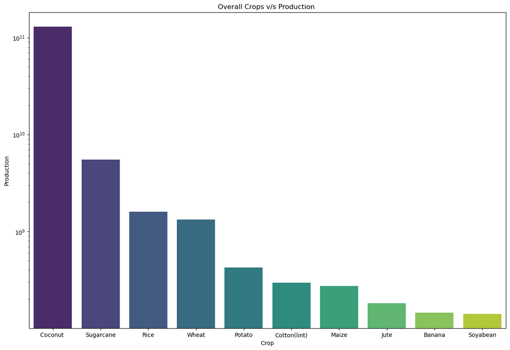

```python
plt.figure(figsize=(15,10))
sns.barplot(x='Crop', y='Production', data = crop1,palette='viridis')
plt.yscale('log')
plt.title('Overall Crops v/s Production ')
plt.show()
```

- The crops with maximum production are: Coconut, Sugarcane, Rice

## 3. Year wise production

```python
year_wise_prod = df.groupby(by='Crop_Year')['Production'].sum().reset_index().sort_values(by='Production', ascending=False)
year_wise_prod
```

[output not shown]

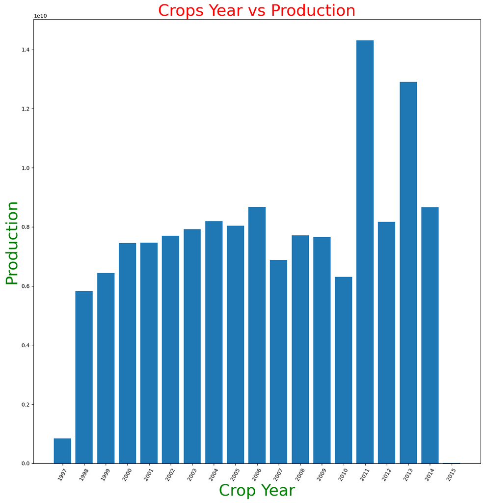

```python
plt.figure(figsize=(15,15))
plt.bar(year_wise_prod.Crop_Year, year_wise_prod.Production, width=0.8)

plt.xticks(year_wise_prod.Crop_Year, rotation = 60)
plt.xlabel("Crop Year", fontsize = 30, color = 'g')
plt.ylabel("Production", fontsize = 30, color = 'g')
plt.title('Crops Year vs Production', fontsize = 30, color = 'r')
```

- The production was maximum in years - 2011 and 2013

## 4. Season wise Production

```python
season_wise_prod = df.groupby(by='Season')['Production'].sum().reset_index().sort_values(by='Production', ascending=False).head(10)
season_wise_prod
```

[output not shown]

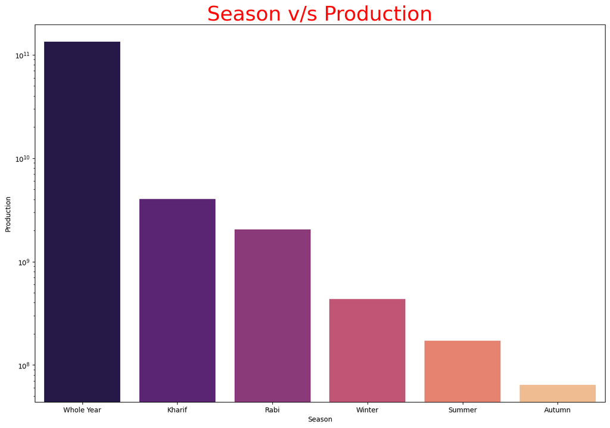

```python
plt.figure(figsize=(15,10))
sns.barplot(x='Season', y='Production',data = season_wise_prod, palette='magma')
plt.yscale('log')
plt.title('Season v/s Production', fontsize = 30,color = 'r')
plt.show()
```

- Top crop categories which shows high production values are Whole Year(Annual growing plants), Kharif and Rabi crops.
- These crop are generally dependent on monsoons.

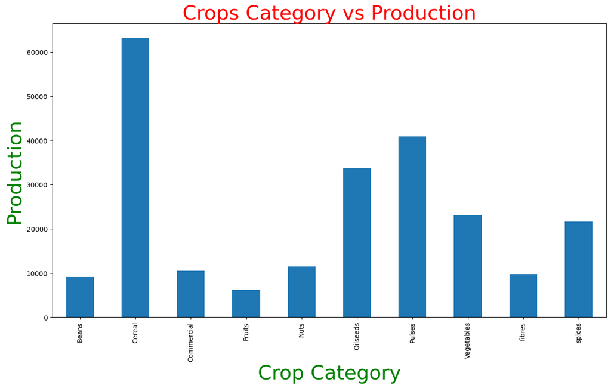

```python
plt.figure(figsize=(15,8))
plt.tick_params(labelsize=10)
df.groupby("crop_category")["Production"].agg("count").plot.bar()
plt.xlabel("Crop Category",  fontsize = 30, color = 'g')
plt.ylabel("Production", fontsize = 30, color = 'g')
plt.title('Crops Category vs Production', fontsize = 30, color = 'r')
plt.show()
```

## 6. Different proportion of crop categories for india

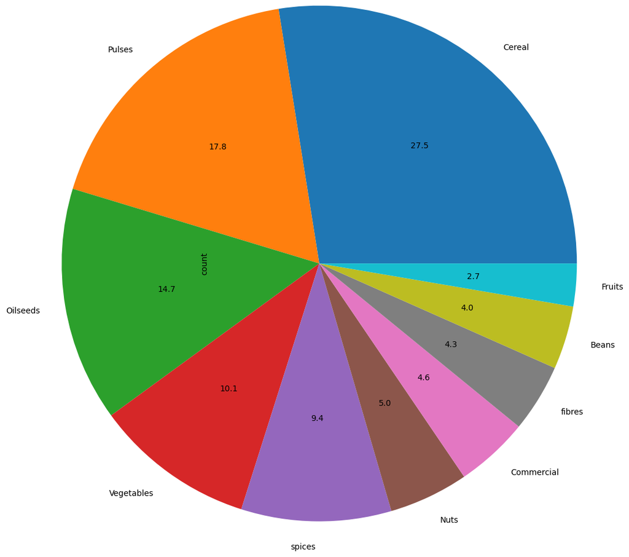

```python
df1=df["crop_category"].value_counts()
df1.plot(radius=3,kind="pie",autopct="%1.1f",pctdistance=0.6)
plt.tick_params(labelsize=10)
```

Top producing crop categories are

- Cereals - 27.5%
- Pulses - 17.8%
- Oilseeds - 14.7%

## State wise crop production with different categories of crops

```python
state_wise = pd.crosstab(df['State_Name'],df['crop_category'])
state_wise
```

| crop_category State_Name | Beans | Cereal | Commercial | Fruits | Nuts | Oilseeds | Pulses | Vegetables | fibres | spices |
| --- | --- | --- | --- | --- | --- | --- | --- | --- | --- | --- |
| Andaman and Nicobar Islands | 0 | 20 | 15 | 16 | 37 | 11 | 9 | 20 | 0 | 52 |
| Andhra Pradesh | 386 | 2264 | 474 | 502 | 674 | 1101 | 1336 | 1046 | 333 | 802 |
| Arunachal Pradesh | 26 | 1021 | 168 | 0 | 26 | 343 | 67 | 257 | 0 | 637 |
| Assam | 0 | 2952 | 854 | 920 | 400 | 2097 | 2234 | 1781 | 1284 | 1338 |
| Bihar | 280 | 6108 | 756 | 226 | 130 | 2504 | 3731 | 1775 | 924 | 1396 |
| Chandigarh | 0 | 39 | 0 | 0 | 0 | 7 | 14 | 26 | 0 | 0 |
| Chhattisgarh | 646 | 1805 | 316 | 264 | 261 | 1496 | 2087 | 1143 | 535 | 1288 |
| Dadra and Nagar Haveli | 0 | 116 | 12 | 9 | 9 | 30 | 64 | 0 | 13 | 1 |
| Goa | 0 | 62 | 22 | 16 | 47 | 0 | 32 | 0 | 0 | 12 |
| Gujarat | 403 | 2466 | 372 | 157 | 683 | 1029 | 1521 | 473 | 327 | 512 |
| Haryana | 108 | 1427 | 259 | 52 | 126 | 543 | 860 | 463 | 257 | 248 |
| Himachal Pradesh | 179 | 726 | 67 | 0 | 54 | 236 | 530 | 214 | 37 | 345 |
| Jammu and Kashmir | 12 | 562 | 42 | 24 | 7 | 233 | 307 | 196 | 44 | 115 |
| Jharkhand | 0 | 575 | 16 | 0 | 0 | 124 | 304 | 247 | 0 | 0 |
| Karnataka | 1096 | 5295 | 615 | 598 | 1470 | 3135 | 2776 | 1763 | 605 | 2588 |
| Kerala | 3 | 819 | 236 | 437 | 536 | 168 | 13 | 636 | 12 | 863 |
| Madhya Pradesh | 962 | 5115 | 826 | 659 | 768 | 3281 | 3993 | 2738 | 922 | 2739 |
| Maharashtra | 477 | 4009 | 458 | 83 | 868 | 3189 | 2326 | 56 | 465 | 0 |
| Manipur | 31 | 151 | 40 | 228 | 4 | 49 | 160 | 347 | 12 | 226 |
| Meghalaya | 113 | 606 | 182 | 162 | 143 | 329 | 314 | 399 | 177 | 442 |
| Mizoram | 42 | 230 | 123 | 0 | 15 | 143 | 213 | 96 | 64 | 0 |
| Nagaland | 211 | 1054 | 160 | 0 | 144 | 718 | 873 | 302 | 197 | 131 |
| Odisha | 629 | 3871 | 607 | 0 | 1156 | 2335 | 1760 | 909 | 284 | 912 |
| Puducherry | 0 | 198 | 30 | 73 | 98 | 51 | 101 | 84 | 33 | 89 |
| Punjab | 104 | 1123 | 216 | 0 | 75 | 496 | 728 | 0 | 186 | 0 |
| Rajasthan | 871 | 2634 | 518 | 257 | 444 | 1713 | 2174 | 1048 | 672 | 1256 |
| Sikkim | 72 | 391 | 0 | 8 | 0 | 91 | 136 | 8 | 0 | 0 |
| Tamil Nadu | 479 | 2680 | 623 | 992 | 1076 | 1235 | 1466 | 1827 | 556 | 1442 |
| Telangana | 259 | 1365 | 250 | 201 | 338 | 774 | 882 | 416 | 191 | 576 |
| Tripura | 0 | 240 | 80 | 0 | 119 | 144 | 469 | 20 | 220 | 0 |
| Uttar Pradesh | 1112 | 9719 | 1741 | 269 | 958 | 4028 | 6549 | 3734 | 724 | 2529 |
| Uttarakhand | 360 | 1423 | 127 | 0 | 76 | 626 | 1236 | 511 | 1 | 407 |
| West Bengal | 254 | 2217 | 356 | 0 | 730 | 1542 | 1633 | 619 | 710 | 692 |

# Some Questions and Answers

## 1. Which Crop is seen in high frequency and when and where is it grown in India?

```python
df.Crop.value_counts().head(10)
```

```
Crop
Rice                 15082
Maize                13787
Moong(Green Gram)    10106
Urad                  9710
Sesamum               8821
Groundnut             8770
Wheat                 7878
Sugarcane             7827
Rapeseed &Mustard     7533
Arhar/Tur             7476
Name: count, dtype: int64
```

```python
rice_df = df[df['Crop'] == 'Rice']
rice_df.head(10)
```

|  | State_Name | District_Name | Crop_Year | Season | Crop | Area | Production | crop_category | Production_per_unit_area |
| --- | --- | --- | --- | --- | --- | --- | --- | --- | --- |
| 2 | Andaman and Nicobar Islands | NICOBARS | 2000 | Kharif | Rice | 102.00 | 321.00 | Cereal | 3.147059 |
| 12 | Andaman and Nicobar Islands | NICOBARS | 2001 | Kharif | Rice | 83.00 | 300.00 | Cereal | 3.614458 |
| 18 | Andaman and Nicobar Islands | NICOBARS | 2002 | Kharif | Rice | 189.20 | 510.84 | Cereal | 2.700000 |
| 27 | Andaman and Nicobar Islands | NICOBARS | 2003 | Kharif | Rice | 52.00 | 90.17 | Cereal | 1.734038 |
| 36 | Andaman and Nicobar Islands | NICOBARS | 2004 | Kharif | Rice | 52.94 | 72.57 | Cereal | 1.370797 |
| 45 | Andaman and Nicobar Islands | NICOBARS | 2005 | Kharif | Rice | 2.09 | 12.06 | Cereal | 5.770335 |
| 64 | Andaman and Nicobar Islands | NICOBARS | 2010 | Autumn | Rice | 3.50 | 10.00 | Cereal | 2.857143 |
| 81 | Andaman and Nicobar Islands | NORTH AND MIDDLE ANDAMAN | 2000 | Kharif | Rice | 10779.00 | 31863.00 | Cereal | 2.956026 |
| 92 | Andaman and Nicobar Islands | NORTH AND MIDDLE ANDAMAN | 2001 | Kharif | Rice | 9718.00 | 27033.00 | Cereal | 2.781745 |
| 98 | Andaman and Nicobar Islands | NORTH AND MIDDLE ANDAMAN | 2006 | Kharif | Rice | 6854.30 | 18995.62 | Cereal | 2.771344 |

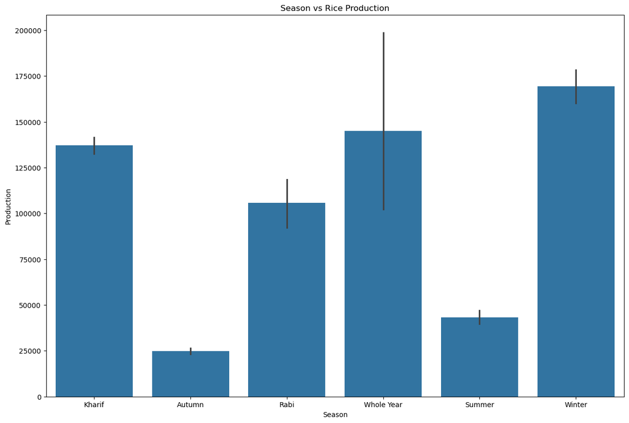

```python
fig, ax = plt.subplots(figsize=(15,10))
sns.barplot(x="Season",y="Production",data=rice_df);
plt.title('Season vs Rice Production')
plt.show()
```

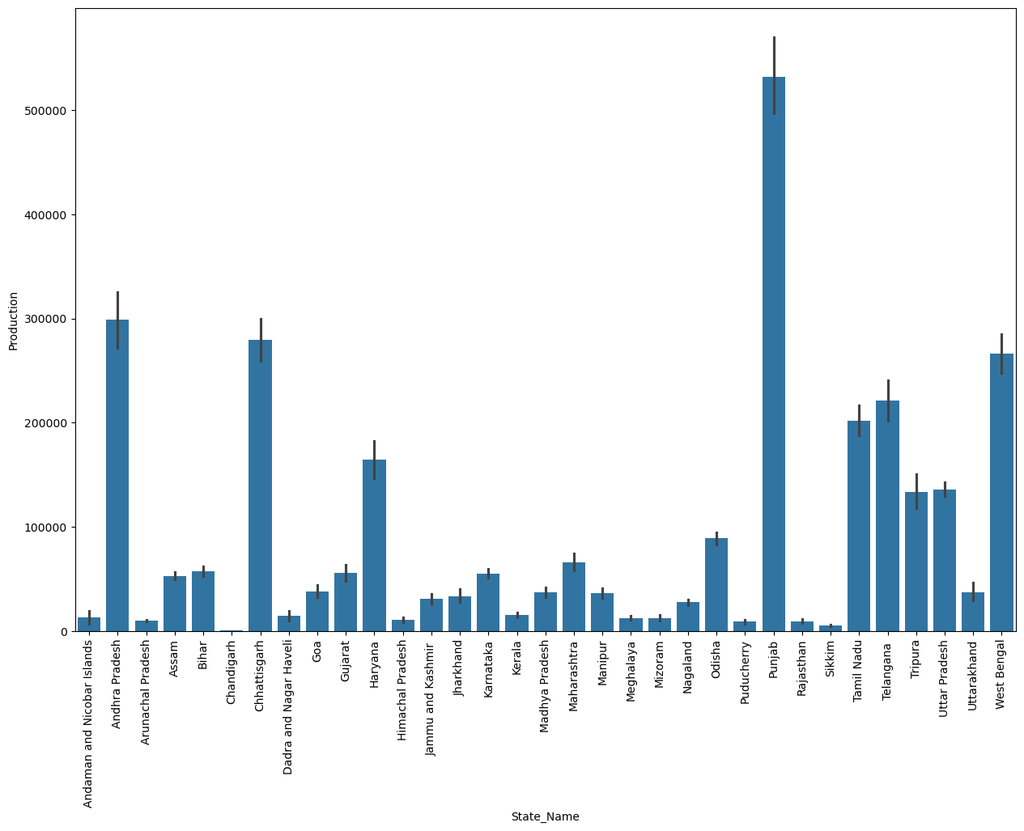

```python
plt.figure(figsize=(15,10))
sns.barplot(x="State_Name",y="Production",data=rice_df)
plt.xticks(rotation=90)
plt.show()
```

```python
rice_prod_dis = rice_df.groupby("District_Name")["Production"].sum().reset_index().sort_values(by='Production',ascending=False)
sum_rice = rice_prod_dis["Production"].sum()
rice_prod_dis["Percent_of_Production"] = rice_prod_dis["Production"].map(lambda x:(x/sum_rice)*100)
rice_prod_dis.head(10)
```

|  | District_Name | Production | Percent_of_Production |
| --- | --- | --- | --- |
| 58 | BARDHAMAN | 34239976.0 | 2.132707 |
| 374 | MEDINIPUR WEST | 29192719.0 | 1.818328 |
| 612 | WEST GODAVARI | 27845309.0 | 1.734402 |
| 169 | EAST GODAVARI | 24690929.0 | 1.537925 |
| 494 | SANGRUR | 24448000.0 | 1.522794 |
| 325 | KRISHNA | 20280606.0 | 1.263219 |
| 90 | BIRBHUM | 19753571.0 | 1.230391 |
| 347 | LUDHIANA | 18950000.0 | 1.180339 |
| 386 | MURSHIDABAD | 18403217.0 | 1.146282 |
| 214 | GUNTUR | 18245831.0 | 1.136479 |

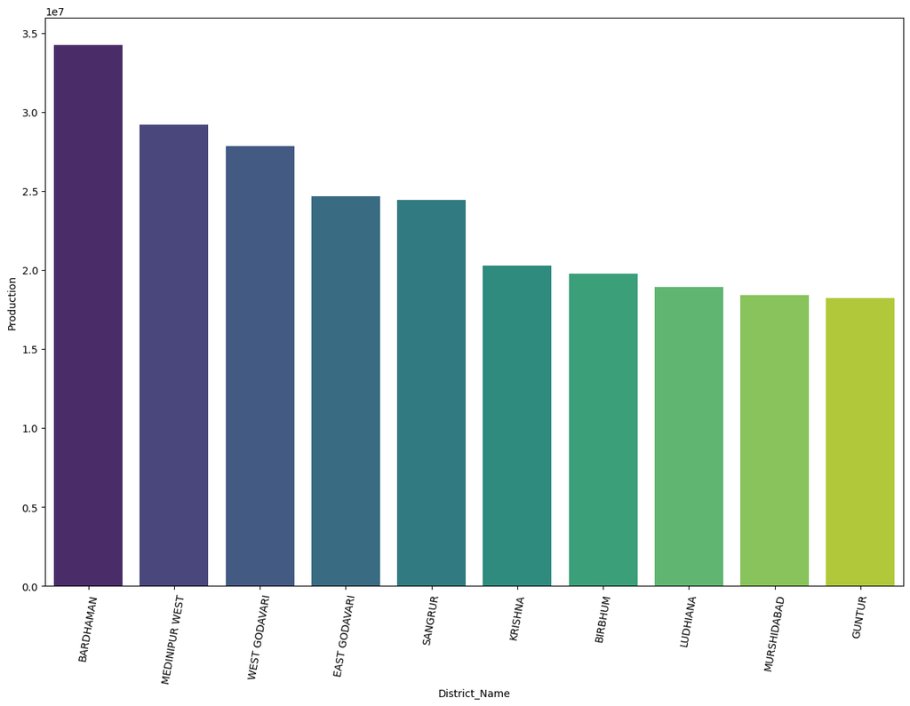

```python
plt.figure(figsize=(15,10))
sns.barplot(x="District_Name",y="Production",data=rice_prod_dis.head(10), palette='viridis')
plt.xticks(rotation=80)
plt.show()
```

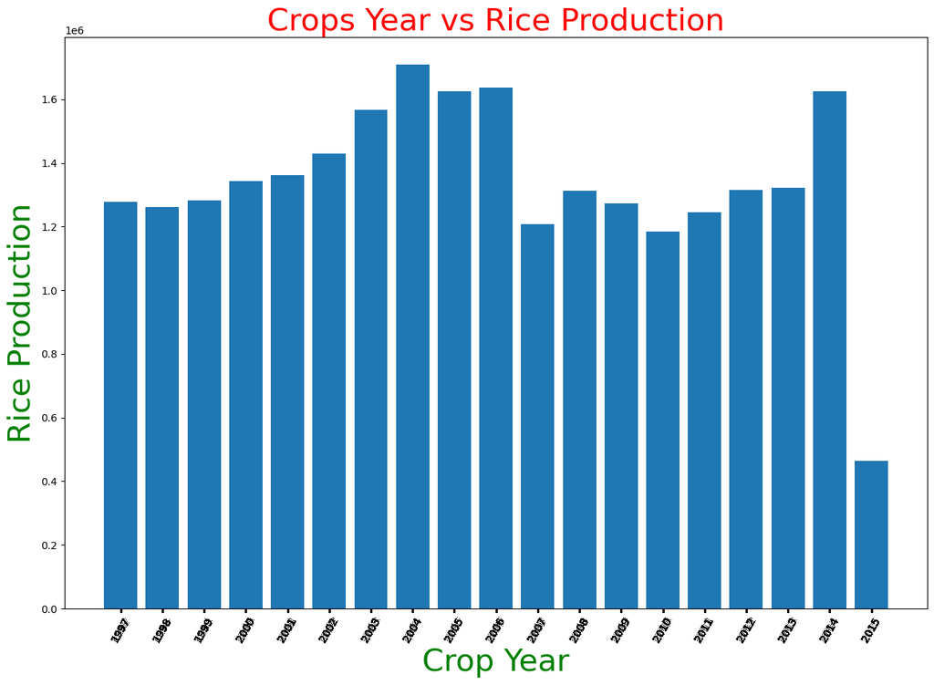

```python
plt.figure(figsize= (15,10))
x= rice_df['Crop_Year']
y= rice_df["Production"]
plt.xticks(rice_df['Crop_Year'], rotation = 60)
plt.xlabel("Crop Year",  fontsize = 30, color = 'g')
plt.ylabel("Rice Production",  fontsize = 30, color = 'g')
plt.title('Crops Year vs Rice Production',  fontsize = 30, color = 'r')
plt.bar(x,y)
plt.show()
```

### Answers

- Rice is seen to have more frequency.
- Rice is grown majorly in Winter.
- State wise Punjab dominates in rice production
- District wise its BARDHAMAN(2.13%), MEDINIPUR WEST(1.8%) and WEST GODAVARI(1.73%) which contributes to total rice production.
- Year wise 2004 is the year when production reached the peak production.

## 2. Which states ranks high in area wise crop production in India? Substantiate with facts and Figures.

```python
df_area = df.groupby('State_Name')['Area'].sum().reset_index().sort_values(by='Area', ascending=False)
df_area.head(10)
```

|  | State_Name | Area |
| --- | --- | --- |
| 30 | Uttar Pradesh | 4.336223e+08 |
| 16 | Madhya Pradesh | 3.297913e+08 |
| 17 | Maharashtra | 3.221860e+08 |
| 25 | Rajasthan | 2.687882e+08 |
| 32 | West Bengal | 2.154030e+08 |
| 14 | Karnataka | 2.029086e+08 |
| 9 | Gujarat | 1.549261e+08 |
| 1 | Andhra Pradesh | 1.315073e+08 |
| 4 | Bihar | 1.282695e+08 |
| 24 | Punjab | 1.267152e+08 |

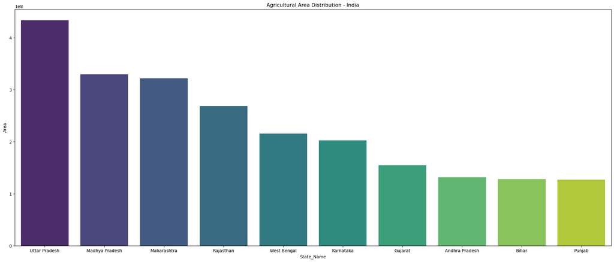

```python
fig, ax = plt.subplots(figsize=(25,10))
sns.barplot(x='State_Name', y='Area',data= df_area.head(10) ,errwidth=0, palette='viridis')
plt.title('Agricultural Area Distribution - India');
```

- Top cultivating states based on the Cultivation area are: Uttar Pradesh, Madhya Pradesh and Maharashtra.

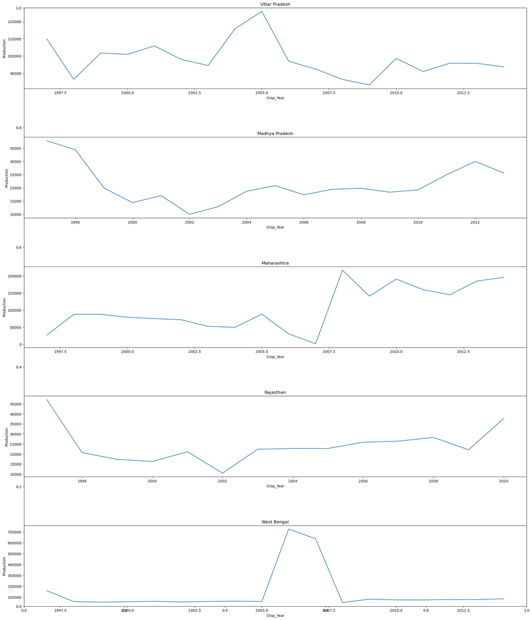

```python
df_area_5 = df_area.head(5)

fig, ax = plt.subplots(figsize=(25,30), sharey='col')
count = 1

for state in df_area_5.State_Name.unique():
    plt.subplot(len(df_area_5.State_Name.unique()),1,count)
    sns.lineplot(x=df[df.State_Name==state]['Crop_Year'],y=df[df.State_Name==state]['Production'], ci=None)
    plt.subplots_adjust(hspace=0.6)
    plt.title(state)
    count+=1;
```

- Uttar Pradesh - High Production was seen in 2005 and after that it’s been reducing gradually.
- Madhya Pradesh - 1998 showed a high production and then there was gradual reduction but it picked up and 2012 also showed a peak in Production.
- Maharashtra - Production went down drastically in 2006 and again the levels went up and hit a high peak after 2007.
- Rajasthan - Production hit a all time low in the year 2002 and then picked up by 2010.
- West Bengal - Production hit a peak around 2006 but it has hit a low after 2007 and never recovered back.

## 3. Find the most efficient state (in terms of most production per unit area). Also find the most efficient state for some of the crop categories.

```python
efficiency = df.groupby('State_Name')['Production_per_unit_area'].mean().reset_index().sort_values(by='Production_per_unit_area', ascending=False)
efficiency.head(10)
```

|  | State_Name | Production_per_unit_area |
| --- | --- | --- |
| 23 | Puducherry | 763.596415 |
| 15 | Kerala | 381.272231 |
| 24 | Punjab | 345.754577 |
| 0 | Andaman and Nicobar Islands | 343.553142 |
| 8 | Goa | 199.160564 |
| 1 | Andhra Pradesh | 195.138587 |
| 3 | Assam | 148.630468 |
| 28 | Telangana | 101.211017 |
| 27 | Tamil Nadu | 65.287593 |
| 32 | West Bengal | 53.334813 |

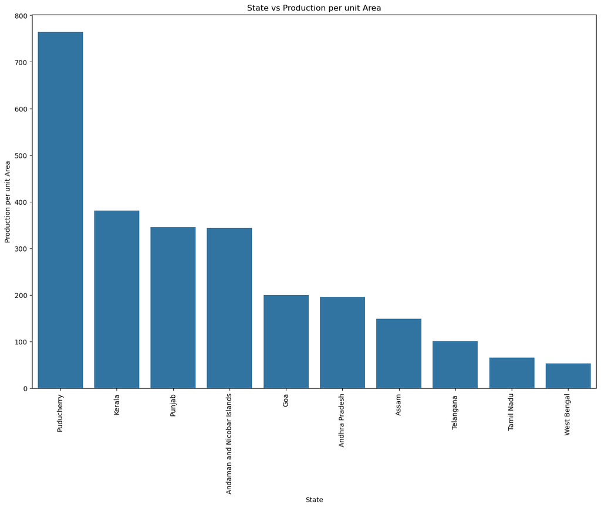

```python
fig, ax = plt.subplots(figsize=(15,10))
a = sns.barplot(x='State_Name', y='Production_per_unit_area',data = efficiency.head(10), errwidth=0)
plt.title('State vs Production per unit Area');
plt.xlabel("State")
plt.ylabel("Production per unit Area")
a.set_xticklabels(
    labels=efficiency.State_Name.head(10), rotation=90)
plt.show()
```

- Most efficieent states in terms of production per unit area are - Puducherry, Kerala and Punjab.

```python
df.crop_category.unique()
```

```
array(['Nuts', 'Pulses', 'Cereal', 'Fruits', None, 'spices', 'Commercial',
       'Vegetables', 'Oilseeds', 'fibres', 'Beans'], dtype=object)
```

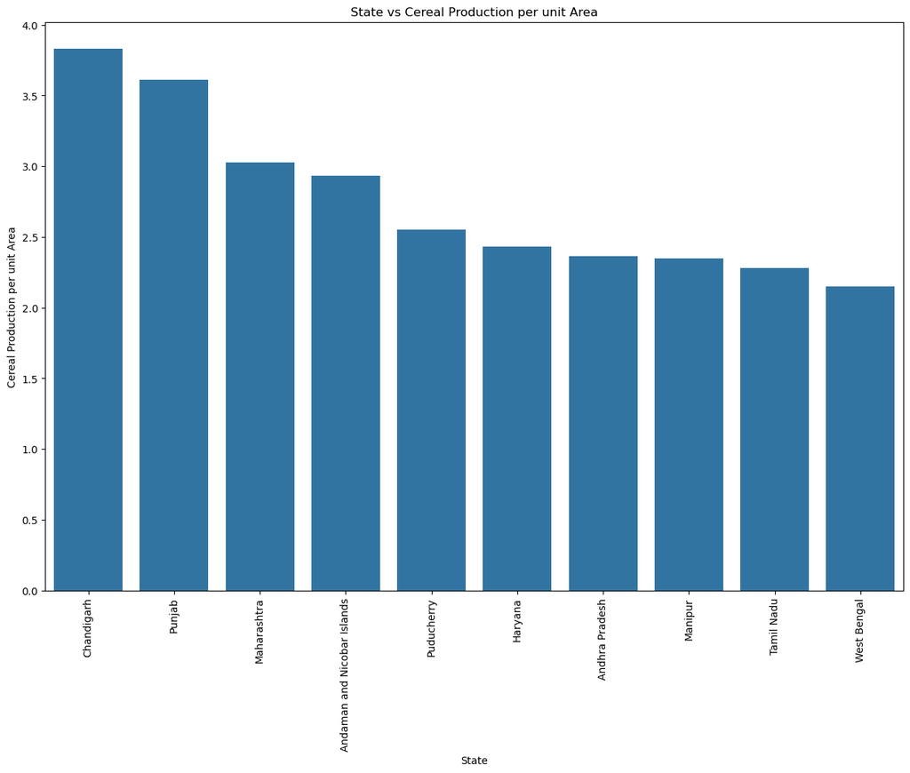

```python
cereal_df = df[df["crop_category"]=="Cereal"]

efficiency_cereal = cereal_df.groupby('State_Name')['Production_per_unit_area'].mean().reset_index().sort_values(by='Production_per_unit_area', ascending=False)
efficiency_cereal.head(10)

fig, ax = plt.subplots(figsize=(15,10))
b = sns.barplot(x='State_Name', y='Production_per_unit_area',data = efficiency_cereal.head(10) ,errwidth=0)
plt.title('State vs Cereal Production per unit Area');
plt.xlabel("State")
plt.ylabel("Cereal Production per unit Area")
b.set_xticklabels(
    labels=efficiency_cereal.State_Name.head(10), rotation=90)
plt.show()
```

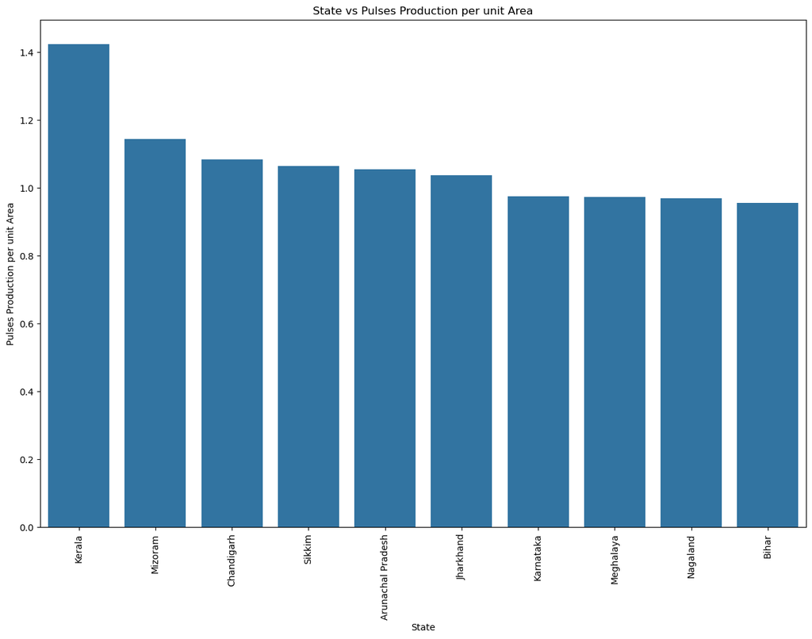

```python
pulses_df = df[df["crop_category"]=="Pulses"]

efficiency_pulses = pulses_df.groupby('State_Name')['Production_per_unit_area'].mean().reset_index().sort_values(by='Production_per_unit_area', ascending=False)
efficiency_pulses.head(10)

fig, ax = plt.subplots(figsize=(15,10))
b = sns.barplot(x='State_Name', y='Production_per_unit_area',data = efficiency_pulses.head(10), errwidth=0)
plt.title('State vs Pulses Production per unit Area');
plt.xlabel("State")
plt.ylabel("Pulses Production per unit Area")
b.set_xticklabels(
    labels=efficiency_pulses.State_Name.head(10), rotation=90)
plt.show()
```

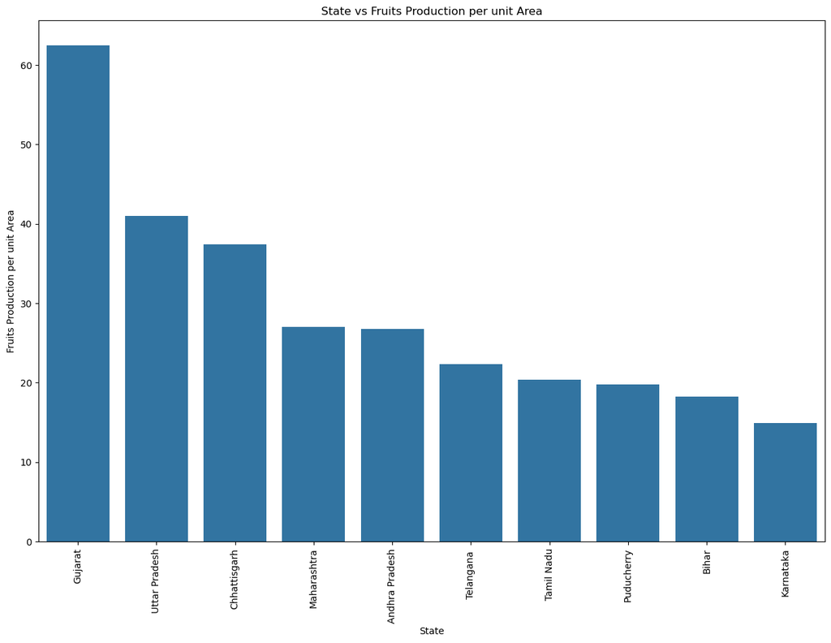

```python
fruits_df = df[df["crop_category"]=="Fruits"]

efficiency_fruits = fruits_df.groupby('State_Name')['Production_per_unit_area'].mean().reset_index().sort_values(by='Production_per_unit_area', ascending=False)
efficiency_fruits.head(10)

fig, ax = plt.subplots(figsize=(15,10))
b = sns.barplot(x='State_Name', y='Production_per_unit_area',data = efficiency_fruits.head(10), errwidth=0)
plt.title('State vs Fruits Production per unit Area');
plt.xlabel("State")
plt.ylabel("Fruits Production per unit Area")
b.set_xticklabels(
    labels=efficiency_fruits.State_Name.head(10), rotation=90)
plt.show()
```

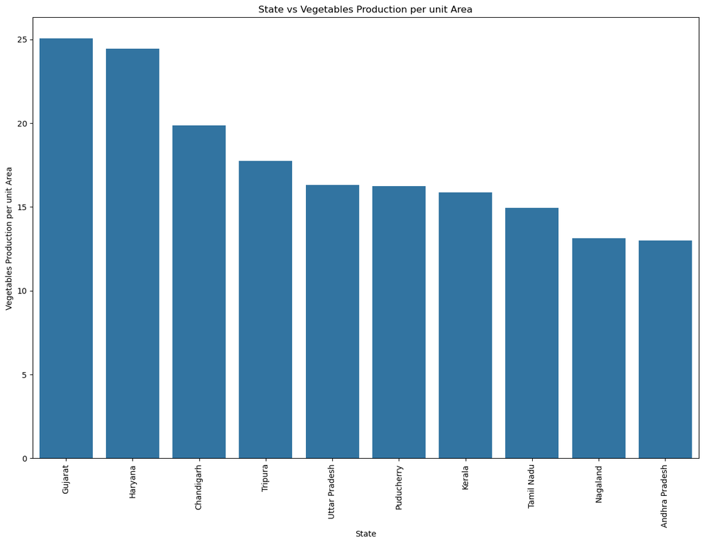

```python
veg_df = df[df["crop_category"]=="Vegetables"]

efficiency_veg = veg_df.groupby('State_Name')['Production_per_unit_area'].mean().reset_index().sort_values(by='Production_per_unit_area', ascending=False)
efficiency_veg.head(10)

fig, ax = plt.subplots(figsize=(15,10))
b = sns.barplot(x='State_Name', y='Production_per_unit_area',data = efficiency_veg.head(10), errwidth=0)
plt.title('State vs Vegetables Production per unit Area');
plt.xlabel("State")
plt.ylabel("Vegetables Production per unit Area")
b.set_xticklabels(
    labels=efficiency_veg.State_Name.head(10), rotation=90)
plt.show()
```

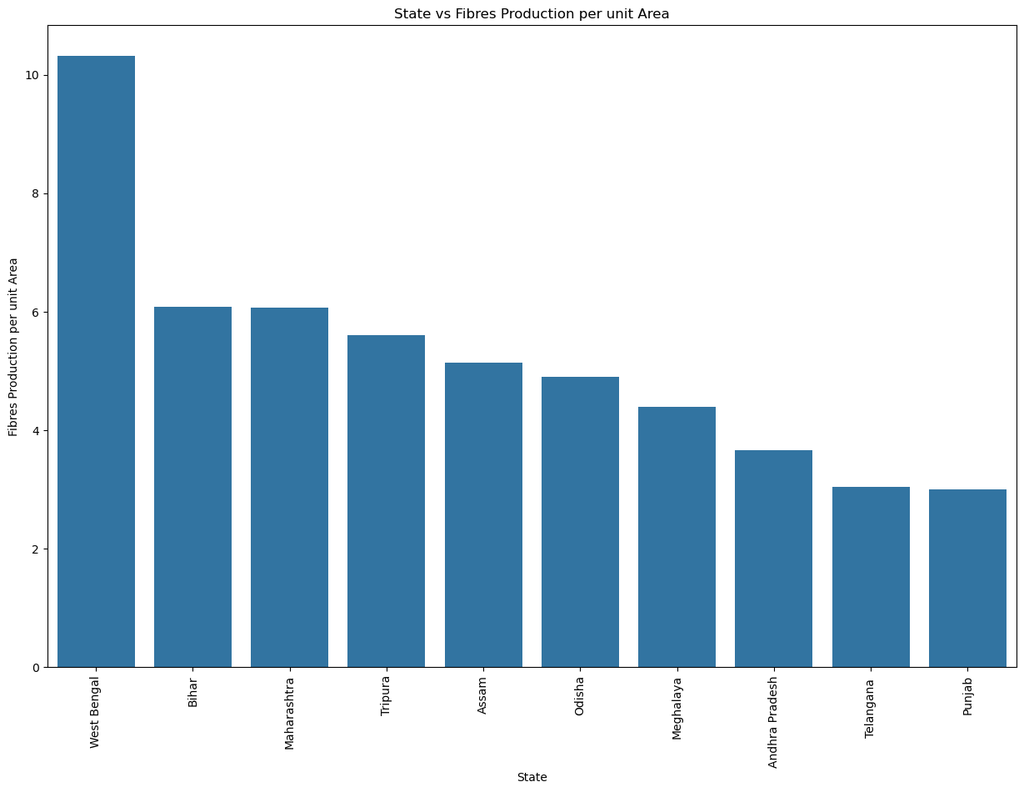

```python
fibres_df = df[df["crop_category"]=="fibres"]

efficiency_fibres = fibres_df.groupby('State_Name')['Production_per_unit_area'].mean().reset_index().sort_values(by='Production_per_unit_area', ascending=False)
efficiency_fibres.head(10)

fig, ax = plt.subplots(figsize=(15,10))
b = sns.barplot(x='State_Name', y='Production_per_unit_area',data = efficiency_fibres.head(10), errwidth=0)
plt.title('State vs Fibres Production per unit Area');
plt.xlabel("State")
plt.ylabel("Fibres Production per unit Area")
b.set_xticklabels(
    labels=efficiency_fibres.State_Name.head(10), rotation=90)
plt.show()
```

Most efficieent states in terms of production per unit area for various categories of crops are-

- Cereals - Chandigarh
- Pulses - Kerala
- Fruits - Gujrat
- Vegetables - Gujrat
- Fibres - West Bengal

# Inferences and Conclusion

#### Univarate-Analysis

- State_Name - 33 Names including Union territories. Top states contributing to dataset are Uttar Pardesh, Madhya Pradesh and Karnataka.
- Crop_Year - Dataset represents data for 19 years from 1997 to 2015 and maximum data from 2003, 2002 & 2007.
- Season - We see six seasons with maximum data from Kharif, Rabi and Whole year.
- Crop - We data for 124 different crops with maximum data from Rice, Maize and Moong(Green Gram).
- Area: Huge margin area used for production from 1 to 8580100 unit area. Distribution is highly right skewed due to lot of outliers.
- Production value ranges from 0 to 1.25e+09 and Distribution is highly right skewed due to lot of outliers.

### New Variables created

- crop_category - 124 crops were divided into Cereal, Pulses, oilseeds, Vegetables, spices, Nuts, Commercial, fibers, Beans, Fruits. Dateset shows top categories are Cereal, Pulses and oilseeds.
- prod_per_unit_area - This variable was created as by dividing production with the area.

### Visualisation of Data

1. State wise Production
2. Crop wise Production
3. Year wise Production
4. Season wise Production
5. Crop Category wise Production
6. Different Proportion of crop Categories

### Questions and Answers

1. Which Crop is seen in high frequency and when and where is it grown in India?
   - Rice is seen to have more frequency.
   - Rice is grown majorly in Winter.
   - State wise Punjab dominates in rice production
   - District wise its BARDHAMAN(2.13%), MEDINIPUR WEST(1.8%) and WEST GODAVARI(1.73%) which contributes to total rice production.
   - Year wise 2004 is the year when production reached the peak production.
2. Which states ranks high in area wise crop production in India? Substantiate with facts and Figures.
   - Top cultivating states based on the Cultivation area are: Uttar Pradesh, Madhya Pradesh, Maharashtra, Rajasthan and West Bengal.
   - Year wise trend of these states:
     - Uttar Pradesh - High Production was seen in 2005 and after that it’s been reducing gradually.
     - Madhya Pradesh - 1998 showed a high production and then there was gradual reduction but it picked up and 2012 also showed a peak in Production.
     - Maharashtra - Production went down drastically in 2006 and again the levels went up and hit a high peak after 2007.
     - Rajasthan - Production hit a all time low in the year 2002 and then picked up by 2010.
     - West Bengal - Production hit a peak around 2006 but it has hit a low after 2007 and never recovered back.
3. Find the most efficient state (in terms of most production per unit area). Also find the most efficient state for some of the crop categories.
   - Most efficieent states in terms of production per unit area are - Puducherry, Kerala and Punjab.
   - Most efficieent states in terms of production per unit area for various categories of crops are:
     - Cereals - Chandigarh
     - Pulses - Kerala
     - Fruits - Gujrat
     - Vegetables - Gujrat
     - Fibres - West Bengal